# Retina_Images_Processing

## Using the Colab GPU.

We can train neural networks much faster using a dedicated graphics processing unit (GPU). Fortunately, Google Colab provides free access to GPU instances. Therefore, we will use the provided GPU for faster training.

Below code cell will check whether the instance is connected to the GPU.

```python
!nvidia-smi
#Check allocated GPU
```

```
Mon May  8 12:43:12 2023
+-----------------------------------------------------------------------------+
| NVIDIA-SMI 525.85.12    Driver Version: 525.85.12    CUDA Version: 12.0     |
|-------------------------------+----------------------+----------------------+
| GPU  Name        Persistence-M| Bus-Id        Disp.A | Volatile Uncorr. ECC |
| Fan  Temp  Perf  Pwr:Usage/Cap|         Memory-Usage | GPU-Util  Compute M. |
|                               |                      |               MIG M. |
|===============================+======================+======================|
|   0  Tesla T4            Off  | 00000000:00:04.0 Off |                    0 |
| N/A   43C    P8     9W /  70W |      0MiB / 15360MiB |      0%      Default |
|                               |                      |                  N/A |
+-------------------------------+----------------------+----------------------+

+-----------------------------------------------------------------------------+
| Processes:                                                                  |
|  GPU   GI   CI        PID   Type   Process name                  GPU Memory |
|        ID   ID                                                   Usage      |
|=============================================================================|
|  No running processes found                                                 |
+-----------------------------------------------------------------------------+
```

## Import the libraries

```python
import numpy as np
import tensorflow as tf
from tensorflow import keras
from keras import Sequential
import matplotlib.pyplot as plt
```

## Data loading

Processing the entire retinal image will require complex models and techniques. For simplicity, we will use **cropped patches** of the grayscaled retinal image. In total, we will provide 537 pairs of images and corresponding vessel masks for training and 173 pairs for validation.

```python
retinal_vessel_data = np.load('retinal_vessel_dataset.npz')
implementation_check = np.load('sample_data.npz')
x_train_raw = retinal_vessel_data["x_train"][...,np.newaxis]
y_train = retinal_vessel_data["y_train"][...,np.newaxis].astype(int)
x_val_raw = retinal_vessel_data["x_val"][...,np.newaxis]
y_val = retinal_vessel_data["y_val"][...,np.newaxis].astype(int)
print("x_train_raw.shape", x_train_raw.shape)   #Each patch has a shape 64 X 64.
print("y_train.shape", y_train.shape)
print("x_val_raw.shape", x_val_raw.shape)
print("y_val.shape", y_val.shape)
print("y_val.shape", y_val.shape)
```

```
x_train_raw.shape (537, 64, 64, 1)
y_train.shape (537, 64, 64, 1)
x_val_raw.shape (173, 64, 64, 1)
y_val.shape (173, 64, 64, 1)
y_val.shape (173, 64, 64, 1)
```

## Lets visualize some examples

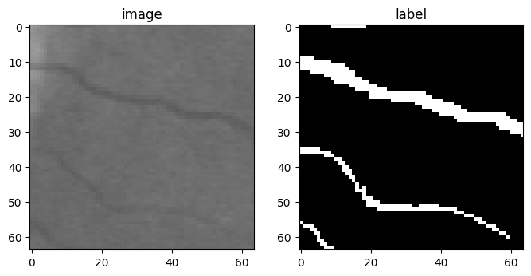

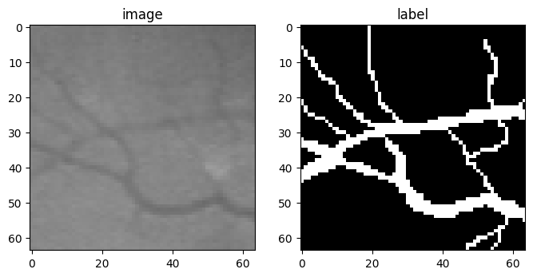

```python
# Helper functions for visualization
def visualize_side_by_side(img1, img1caption,
                            img2, img2caption,
                            img2range = (0,255), img1range = (0,255)):

    fig, axs = plt.subplots(1,2, figsize=(8,16))
    axs[0].imshow(img1,cmap='gray',vmax=img1range[1],vmin=img1range[0])
    axs[1].imshow(img2,cmap='gray',vmax=img2range[1],vmin=img2range[0])
    axs[0].set_title(img1caption)
    axs[1].set_title(img2caption)
    fig.show()

def visualize_side_by_3(img1, img1caption,
                         img2, img2caption,
                         img3, img3caption,
                         img1range = (0,255), img2range = (0,255), img3range = (0,255)):

    fig, axs = plt.subplots(1,3, figsize=(16,24))
    axs[0].imshow(img1,cmap='gray',vmax=img1range[1],vmin=img1range[0])
    axs[1].imshow(img2,cmap='gray',vmax=img2range[1],vmin=img2range[0])
    axs[2].imshow(img3,cmap='gray',vmax=img3range[1],vmin=img3range[0])
    axs[0].set_title(img1caption)
    axs[1].set_title(img2caption)
    axs[2].set_title(img3caption)
    fig.show()


visualize_side_by_side(x_train_raw[21,...], 'image', y_train[21,...], 'label', img2range = (0,1))
visualize_side_by_side(x_train_raw[121,...], 'image', y_train[121,...], 'label', img2range = (0,1))
```

## 1.: Contrast Stretching

As you can see from the above example, retinal images are low-contrast images. In other words, the intensities of the vessels do not stand out by a large margin compared to the background. As such, we will enhance the retinal images by stretching their contrast.

We will use the following contrast stretching formula:

$\mathcal{I}_{new}=\frac{\mathcal{I}-\mathcal{I}_{min}}{\mathcal{I}_{max}-\mathcal{I}_{min}}\times255$, where

- $\mathcal{I}$ is the current pixel intensity value
- $\mathcal{I}_{min}$ is the minimum intensity value present in the whole image
- $\mathcal{I}_{max}$ is the maximum intensity value present in the whole image
- $\mathcal{I}_{new}$ is the new output intensity value.

The `contrast_stretch()` function below performs contrast stretching on the given image data array.

```python
def contrast_stretch(x):
  """ Stretch the contrast of each individual images in the given data array.

  Parameters
  ------------
  x : np.ndarray
      Image data array
  Returns:
  -------------
  np.ndarray
      New image data arary with individually contrast-stretched images.
  """
  x_enhanced = x
  for i in range(len(x)):

    img1d = x_enhanced[i].flatten()
    multi = 255/(max(img1d) - min(img1d))
    x_enhanced[i] = (x_enhanced[i] - min(img1d))* multi
  return x_enhanced


x_train_enhanced = contrast_stretch(x_train_raw)
x_val_enhanced = contrast_stretch(x_val_raw)
```

Below cell can check our implementation of the `contrast_stretch()`. The last print statement will output `True` if the enhanced image is similar enough to the expected enhanced image.

```
True
```

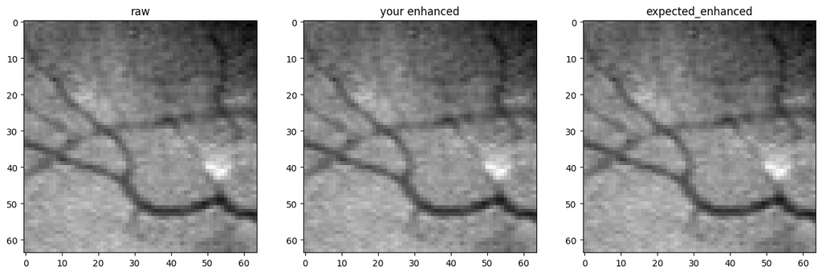

```python
sample_enhanced = implementation_check['sample_enhanced']
your_enhanced = contrast_stretch(x_train_raw)[121] # This code uses 121st training image for comparison.

visualize_side_by_3(x_train_raw[121,...], 'raw', x_train_enhanced[121,...],'your enhanced', sample_enhanced,'expected_enhanced')
print((np.abs(sample_enhanced - your_enhanced.squeeze()) > 1).sum() == 0) # Checks whether the enhanced image is similar enough to the expected enhanced image.
```

## 2. Image Re-scaling

Our contrast-enhanced data arrays `x_train_enhanced` and `x_val_enhanced` are arrays in the range of $[0,255]$. We need to standardize the input by rescaling the pixel values to $[0,1]$.

The `rescale_01()` function re-scales the given image data array to range $[0,1]$.

```python
def rescale_01(x):
  """ Rescales the given image data array to range [0,1].

  Parameters
  ------------
  x : np.ndarray
      image data array

  Returns:
  -------------
  np.ndarray
      New image data arary re-scaled to range [0,1].
  """
  x_01 = x/255
  return x_01.astype(float)

x_train = rescale_01(x_train_enhanced)
x_val = rescale_01(x_val_enhanced)
```

# CNN Model

We will build a special type of CNN model called the **Autoencoder** to perform automatic segmentation of retinal vessels.

### Image Classification with CNN

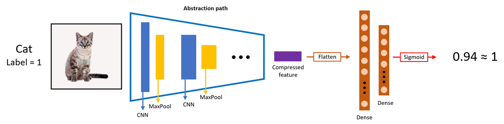

For the CNN image classification model, Image undergoes an "abstraction" path that reduces the spatial dimension of the input via pooling operations while increasing the number of channels with convolution layers along the path. The compressed feature resulting from the abstraction path subsequently gets flattened, from which a set of dense layers further manipulates the flattened features to yield the final classification prediction.

### Autoencoder

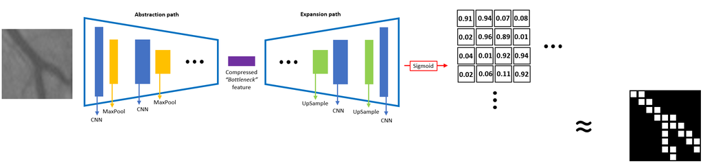

Autoencoder, or an "hourglass" model, is a simple extension of the previously mentioned image classification model. The process of obtaining the compressed feature shares the same concept of **abstraction path** introduced in the classification model. The compressed feature is then propagated to the **expansion** path, which **de-compresses** the compressed feature back to the spatial representation of the image. In this arrangement, the compressed feature is often called the "Bottleneck" feature.

We will use this autoencoder architecture to build a model that can learn to produce a segmentation mask from the input image. Intuitively, we expect the output of the autoencoder to be the predicted segmentation mask. During training, the loss will be computed between the real label mask and the predicted mask.

### UpSampling operation

`tf.keras.layers.UpSampling2D(size=(2, 2), interpolation="nearest")`

For example, an upsampling layer below with size (2, 2) will increase the spatial size by 2 on the horizontal dimension and 2 on the vertical dimension.

For more information, please read the following Keras [documentation](https://keras.io/api/layers/reshaping_layers/up_sampling2d/) on upsampling layer.

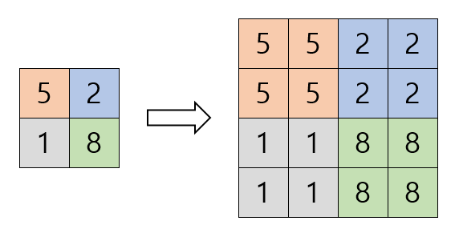

## 3. Build the autoencoder model.

We will implement the autoencoder model using a Keras `Sequential`. Here we provide an architecture of the autoencoder as a baseline. All the layers below can sequentially be added to the `Sequential` model instance to create the autoencoder. Refer to [keras Sequential](https://keras.io/api/models/sequential/) documentation.

Bottleneck path:

Expansion path:

Final Layer:

- A convolutional layer with 1 1*1 kernels

All convolutional layers EXCEPT the final convolutional layer are initialized with ReLU activation, ["He normal"](https://keras.io/api/layers/initializers/#henormal-class) kernel initializer, and `"same"` padding.

The final convolution layer is initialized with Sigmoid activation and He normal kernel initializer.

```python
from keras.layers import Conv2D, MaxPooling2D, UpSampling2D, Dropout

def build_model():
    """
    -------
    keras.Model
        The Sequential model created
    """

    model = Sequential()

    # Abstraction path
    model.add(Conv2D(filters=4, kernel_size=(3, 3), activation='relu',padding='same', kernel_initializer=tf.keras.initializers.HeNormal(), input_shape=(64, 64, 1)))
    model.add(Dropout(0.2))
    model.add(Conv2D(filters=8, kernel_size=(3, 3), activation='relu', padding='same', kernel_initializer=tf.keras.initializers.HeNormal()))
    model.add(MaxPooling2D(pool_size=(2, 2)))


    model.add(Conv2D(filters=16, kernel_size=(3, 3), activation='relu', padding='same', kernel_initializer=tf.keras.initializers.HeNormal()))
    model.add(Dropout(0.2))
    model.add(Conv2D(filters=32, kernel_size=(3, 3), activation='relu', padding='same', kernel_initializer=tf.keras.initializers.HeNormal()))
    model.add(MaxPooling2D(pool_size=(2, 2)))

    # Bottleneck path
    model.add(Conv2D(filters=64, kernel_size=(3, 3), activation='relu', padding='same', kernel_initializer=tf.keras.initializers.HeNormal()))
    model.add(Dropout(0.3))
    model.add(Conv2D(filters=64, kernel_size=(3, 3), activation='relu', padding='same', kernel_initializer=tf.keras.initializers.HeNormal()))

    # Expansion path
    model.add(UpSampling2D(size=(2, 2), interpolation="bicubic"))
    model.add(Conv2D(filters=32, kernel_size=(3, 3), activation='relu', padding='same', kernel_initializer=tf.keras.initializers.HeNormal()))
    model.add(Dropout(0.2))
    model.add(Conv2D(filters=32, kernel_size=(3, 3), activation='relu', padding='same', kernel_initializer=tf.keras.initializers.HeNormal()))

    model.add(UpSampling2D(size=(2, 2), interpolation="nearest"))
    model.add(Conv2D(filters=4, kernel_size=(3, 3), activation='relu', padding='same', kernel_initializer=tf.keras.initializers.HeNormal()))
    model.add(Dropout(0.2))
    model.add(Conv2D(filters=4, kernel_size=(3, 3), activation='relu', padding='same', kernel_initializer=tf.keras.initializers.HeNormal()))

    # Final layer
    model.add(Conv2D(filters=1, kernel_size=(1, 1), activation='sigmoid', kernel_initializer=tf.keras.initializers.HeNormal()))
    ### END YOUR CODE HERE
    model.build((None, 64,64,1))

    return model


model = build_model()
model.summary()
```

```
Model: "sequential_21"
_________________________________________________________________
 Layer (type)                Output Shape              Param #
=================================================================
 conv2d_280 (Conv2D)         (None, 64, 64, 4)         40

 dropout_154 (Dropout)       (None, 64, 64, 4)         0

 conv2d_281 (Conv2D)         (None, 64, 64, 8)         296

 max_pooling2d_42 (MaxPoolin  (None, 32, 32, 8)        0
 g2D)

 conv2d_282 (Conv2D)         (None, 32, 32, 16)        1168

 dropout_155 (Dropout)       (None, 32, 32, 16)        0

 conv2d_283 (Conv2D)         (None, 32, 32, 32)        4640

 max_pooling2d_43 (MaxPoolin  (None, 16, 16, 32)       0
 g2D)

 conv2d_284 (Conv2D)         (None, 16, 16, 64)        18496

 dropout_156 (Dropout)       (None, 16, 16, 64)        0

 conv2d_285 (Conv2D)         (None, 16, 16, 64)        36928

 up_sampling2d_42 (UpSamplin  (None, 32, 32, 64)       0
 g2D)

 conv2d_286 (Conv2D)         (None, 32, 32, 32)        18464

 dropout_157 (Dropout)       (None, 32, 32, 32)        0

 conv2d_287 (Conv2D)         (None, 32, 32, 32)        9248

 up_sampling2d_43 (UpSamplin  (None, 64, 64, 32)       0
 g2D)

 conv2d_288 (Conv2D)         (None, 64, 64, 4)         1156

 dropout_158 (Dropout)       (None, 64, 64, 4)         0

 conv2d_289 (Conv2D)         (None, 64, 64, 4)         148

 conv2d_290 (Conv2D)         (None, 64, 64, 1)         5

=================================================================
Total params: 90,589
Trainable params: 90,589
Non-trainable params: 0
_________________________________________________________________
```

### 4. Compile the model

In Keras' terms, compiling a model is to set the loss function and the optimizer. The following function **receives a model and a learning rate as parameters** and compiles the model using:

- [`binary_crossentropy`](https://keras.io/api/losses/probabilistic_losses/#binarycrossentropy-class) as loss function. In the scope of this assignment, we highly advise that you adhere to this loss function.
- [`Adam`](https://keras.io/api/optimizers/adam/) optimizer that takes the **given learning rate** in the function parameter as an argument.

For more infomation about model compiling, please refer to the [`model.compile`](https://keras.io/api/models/model_training_apis/#compile-method) documentation.

[Other keras optimizers](https://keras.io/api/optimizers) can found in this documentation.

```python
from keras.backend import binary_crossentropy
def compile_model(model, lr):
    """
    Parameters
    ----------
    model : keras.Model
        The model to compile
    lr : float
        The learning rate

    Returns
    -------
    """
    model.compile(optimizer=tf.keras.optimizers.Adam(learning_rate=lr), loss=binary_crossentropy)
    return
```

### 5. Train the model

The following function trains a given model using given `x_train` & `y_train` in a batch size of 16 for a given number of epochs. Also, provide `x_val` & `y_val` as validation data, with a validation batch size of 16 as well.

For more information, please refer to [`model.fit`](https://keras.io/api/models/model_training_apis/#fit-method) documentation.

```python
def train_model(model, epochs, x_train, y_train, x_val, y_val):
    """
    Parameters
    ----------
    model : keras.Model
        The model to train
    epochs : int
        The number of epochs to train
    x_train : np.ndarray
    y_train : np.ndarray
    x_val : np.ndarray
    y_val : np.ndarray

    Returns
    -------
    """
    training_history = model.fit(x_train.astype(float), y_train.astype(float), batch_size=16, epochs=epochs, validation_data=(x_val.astype(float), y_val.astype(float)))
    return
print('x_train.shape', x_train.shape)
print('y_train.shape', y_train.shape)
print('x_val.shape', x_val.shape)
print('y_val.shape', y_val.shape)
```

```
x_train.shape (537, 64, 64, 1)
y_train.shape (537, 64, 64, 1)
x_val.shape (173, 64, 64, 1)
y_val.shape (173, 64, 64, 1)
```

```python
keras.utils.set_random_seed(2211)

learning_rate = 0.001  # learning rate
num_epochs = 50      # no. of epochs

model = build_model() # Build new model with newly initialized weights
compile_model(model, learning_rate)
train_model(model, num_epochs, x_train, y_train, x_val, y_val)
```

### 6. Predict the segmentation masks

Refer to [`model.predict`](https://keras.io/api/models/model_training_apis/#predict-method) documentation.

We will implement a function that predicts the segmented vessels of all the images in the validation image array `x_val` using a batch size of 16. This function would return the prediction results of the model.

For further infomation, please refer to [`model.predict`](https://keras.io/api/models/model_training_apis/#predict-method) documentation.

```python
def predict_model(model, x_val):
    """Predict the segmentation masks of the validation data.

    Parameters
    ----------
    model : keras.Model
        The model to evaluate
    x_val : np.ndarray


    Returns
    ----------
    np.ndarray
        Predicted segmentation array on validation data
    """
    val_preds = model.predict(x=x_val, batch_size=16)

    return val_preds

val_preds = predict_model(model, x_val)
```

Now, let's visualize some of your predicted examples from the validation dataset.

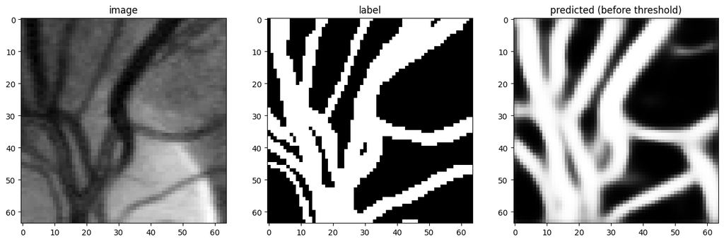

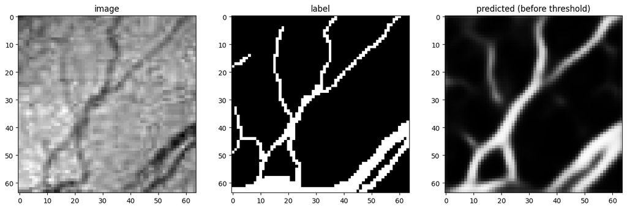

```python
visualize_side_by_3(x_val[12,...], 'image', y_val[12,...], 'label', val_preds[12,...], 'predicted (before threshold)', (0,1),(0,1),(0,1))
visualize_side_by_3(x_val[112,...], 'image', y_val[112,...], 'label', val_preds[112,...], 'predicted (before threshold)', (0,1),(0,1),(0,1))
```

### 7. Mask thresholding

We will implement a function that thresholds the float array within $[0,1]$ range with the value given in the function parameter. For example, for a given threshold of 0.5, values under 0.5 are reduced to zero, while remaining values equal to or larger than 0.5 are all raised to one. Additionally, all thresholded masks would be converted to the integer type.

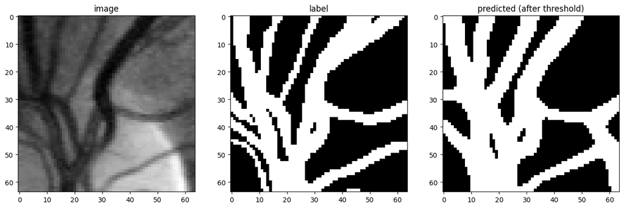

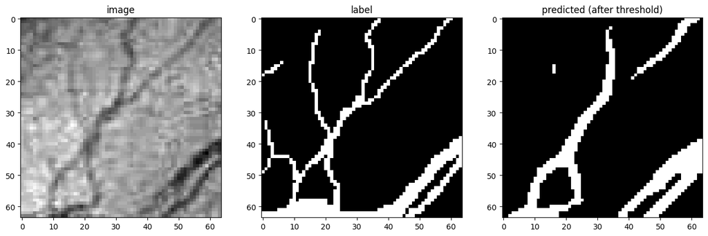

```python
def threshold(val_preds, thresh_value):
    """Threshold the given predicted mask array.

    Parameters
    ----------
    val_preds : np.ndarray
        Predicted segmentation array on validation data
    thresh_value : float

    Returns
    ----------
    np.ndarray
        Thresholded val_preds
    """
    val_preds_thresh = val_preds >= thresh_value
    return val_preds_thresh.astype(int)


val_preds_thresh = threshold(val_preds, 0.5)

visualize_side_by_3(x_val[12,...], 'image', y_val[12,...], 'label', val_preds_thresh[12,...], 'predicted (after threshold)', (0,1),(0,1),(0,1))
visualize_side_by_3(x_val[112,...], 'image', y_val[112,...], 'label', val_preds_thresh[112,...], 'predicted (after threshold)', (0,1),(0,1),(0,1))
```

We can validate the implementation of Task 7 with the code cell below. It will compare the result with the expected sample thresholded mask and return `True` if they are identical.

```
True
```

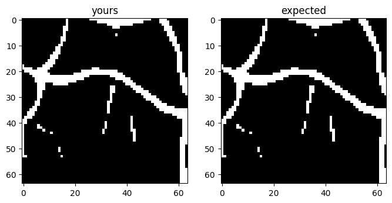

```python
sample_pred_soft = implementation_check['sample_pred_soft']
sample_pred_thresholded = implementation_check['sample_pred_hard']
your_thresholded = threshold(sample_pred_soft, 0.5)
visualize_side_by_side(your_thresholded, 'yours',sample_pred_thresholded,'expected',(0,1),(0,1))
print(np.array_equal(sample_pred_thresholded, your_thresholded)) # Checks whether your thresholded prediction is identical to the expected counterpart.
```

## Evaluation

We will use a evaluation metric called the **Dice coefficient**, one the most dominantly used metrics for segmentation tasks.

### Dice coefficient

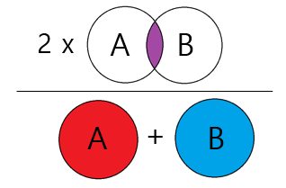

The dice coefficient measures the similarity between two segmentation masks by comparing pixel-wise agreement. It is computed as twice the area of overlap divided by the sum of the areas of both masks. The formula of the dice coefficient is given by the following:

$\frac{2\times |A\cap B|}{|A|+|B|}$

If two masks are identical, the Dice coefficient will give the highest value of 1, and if the two masks have no overlap at all, then it will give the lowest value of 0.

### 8. Implementing Dice coefficient

We will implement the dice coefficient based on the given description. Simply put, the dice coefficient can be computed by dividing twice the area of overlapping vessel pixels by the total vessel areas of the two masks.

Note: **thresholded** prediction masks will be used to compute the dice coefficient.

```python
def dice_coef(mask1, mask2):
    """Calculate the dice coeffecient score between two binary masks.

    Parameters
    ----------
    mask1 : np.ndarray
        binary mask that consists of either 0 or 1.
    mask2 : np.ndarray
        binary mask that consists of either 0 or 1.

    Returns
    ----------
    float
        dice coefficient between mask1 and mask2.
    """
    # Calculate denominator
    total_area = np.sum(mask1) + np.sum(mask2)

    # Calculate numerator
    new_mask_1 = mask1 == 1
    new_mask_2 = mask2 == 1
    both_1 = (new_mask_1.astype(int) + new_mask_2.astype(int)) == 2
    double_overlap = 2*np.sum(both_1.astype(int))

    dice_coef_score = double_overlap/total_area
    return dice_coef_score
```

Below is a sample pairs of real and predicted segmentation masks to check the implementation of the dice coefficient.

```
Dice coefficient: 0.7689
Expected dice coefficient between sample label and sample predicted mask should be 0.7689
```

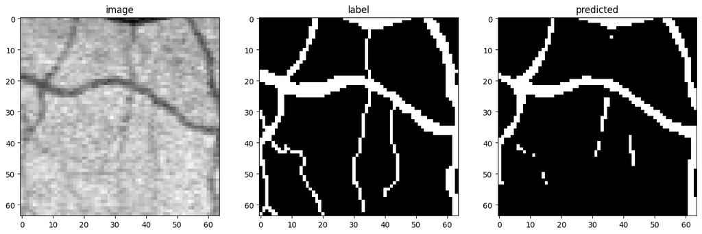

```python
sample_img = implementation_check['sample_img']
sample_label = implementation_check['sample_label']
sample_pred = implementation_check['sample_pred_hard']

visualize_side_by_3(sample_img, 'image', sample_label, 'label', sample_pred, 'predicted', (0,255),(0,1),(0,1))
print("Dice coefficient: {:.4f}".format(dice_coef(sample_label, sample_pred)))
print("Expected dice coefficient between sample label and sample predicted mask should be 0.7689")
```

### 9. Calculate the average dice

Now we have a function that calculates the dice coefficient between two binary segmentation masks. Here, we will obtain the dice coefficient scores of every thresholded predictions on the validation dataset with their corresponding label masks, and average them all to a single value.

```python
def avg_dice(y_val, val_preds_thresh):
    """Calculates the average dice coefficient score across all thresholded predictions & label pair of the validation dataset.

    Parameters
    ----------
    y_val : np.ndarray
        Ground truth segmentation labels array of the validation dataset
    val_preds : np.ndarray
        Predicted segmentation masks array on the validation dataset

    Returns
    ----------
    float
        Average dice score coefficient.
    """
    average_dice_temp = []
    for i in range(len(y_val)):
      dice_coeff = dice_coef(y_val[i], val_preds_thresh[i])
      average_dice_temp.append(dice_coeff)
    average_dice = sum(average_dice_temp)/len(average_dice_temp)
    return average_dice
```

Now, let's test the average dice coefficient score of our model's performance on the validation dataset.

```python
print("{:.4f}".format(avg_dice(y_val, val_preds_thresh)))
```

```
0.7448
```

## 10. Test dataset evaluation

Now we need to evaluate our predicted vessel masks on the test dataset. The code cell below will produce the model's prediction on the test retinal images based on the functions implemented above.

Note: Due to privacy issue, the test dataset and evaluation results will not be shown in this notebook.

```python
# Produce vessel mask prediction on the test retinal images.
x_test_raw = retinal_vessel_data["x_test"][...,np.newaxis]
x_test_enhanced = contrast_stretch(x_test_raw)
x_test = rescale_01(x_test_enhanced)
test_preds = model.predict(x_test, batch_size=16)
test_preds_thresh = threshold(test_preds, 0.5)
np.save('submission.npy', test_preds_thresh)
```

```python
# Saving the model
model.save('trained_model_snapshot.h5')
```